# PFAS Access Database

Instructions & Business Rules

## 1 Background

This document describes how to use the MS Access database to manage PFAS data collected as part of a monitoring effort coordinated by the California State Water Resources Control Board.

## 2 Notes

- The database uses primary keys for all tables to ensure that duplicate data is not imported to the database, so when importing data some records may be rejected if they contain a combination of values in those fields that’s identical to a record already in the database. See Section 4 for more information on database rules used to implement this check.
- The database uses foreign keys to ensure that every monitoring record can be linked to one of the wells included in the study. This is done by ensuring that the `PS_Code` for each monitoring record corresponds to a record with the same `PS_Code` in the `well_list` table. In general, this means that the `well_list` table needs to be populated with information about the wells included in the study before any monitoring data (targeted, non-targeted, or field data) can be loaded into the database. And, if a new well is added to the study, its information has to be added to the `well_list` table before any monitoring data for that well can be imported. See Section 4 for more information on database rules used to implement this check.

## 3 Instructions for Importing Data

Use the following steps to import data from a CSV file:

1. If the name of the first field / column in the CSV file contains a `#` (this should only be the case for the ‘targeted’ data files), manually remove it and save the modified file before uploading.
2. Open the Access database GUI (double click on the `.accdb` file)
3. Go to the `External Data` menu at the top of the window, then select `New Data Source` ➝ `From File` ➝ `Text File`

[figure not shown]

4. In the `Get External Data - Text File` window, browse to the csv file to be uploaded. Then, select the option `Append a copy of the records to the table` and select the corresponding table from the dropdown list. Click the `Ok` button to continue.

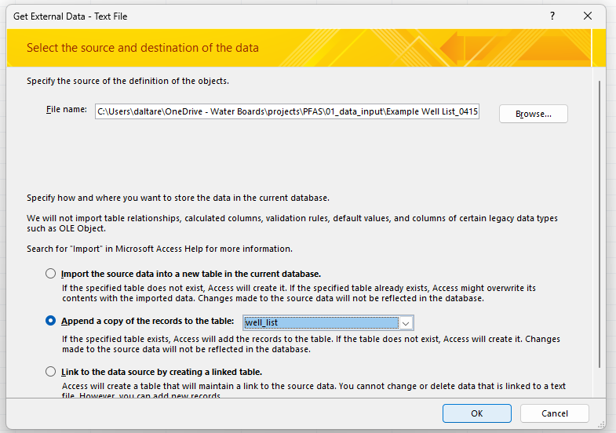

5. In the `Import Text Wizard` window, select the `Delimited` option and click the `Next >` button.

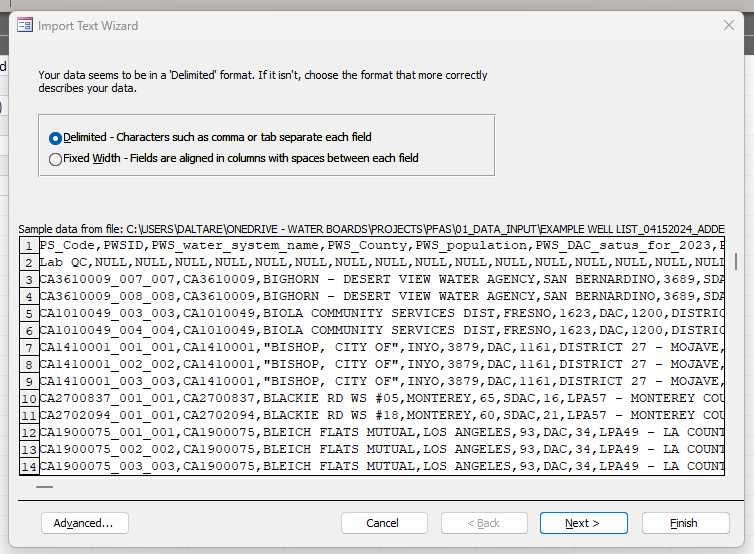

6. In the next window of the `Import Text Wizard`, select `Comma` as the delimiter, check the box that says `First Row Contains Field Names`, and in the `Text Qualifier` dropdown menu select `"` , then click the `Next >` button.

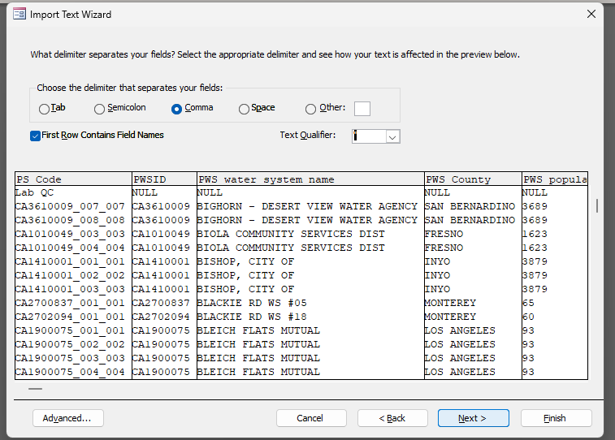

7. **For non-targeted analysis (NTA) only:** To make sure the `Collection_Date` field is imported correctly, use the `Advanced` button in the *Data Import Wizard* to select the date format of the input file (**NOTE:** you’ll probably have to look at the CSV file in a text editor to determine the format of date fields; Excel doesn’t necessarily display the dates in the way they are stored in the CSV file).

   In the `Dates, Times, and Numbers` box select the following options (as shown in the screenshot below) then click the `OK` button:
   1. In the `Date Order` dropdown select: `YMD`
   2. In the `Date Delimiter` box type: `-` (dash)
   3. Check the box for `Leading Zeros in Dates`

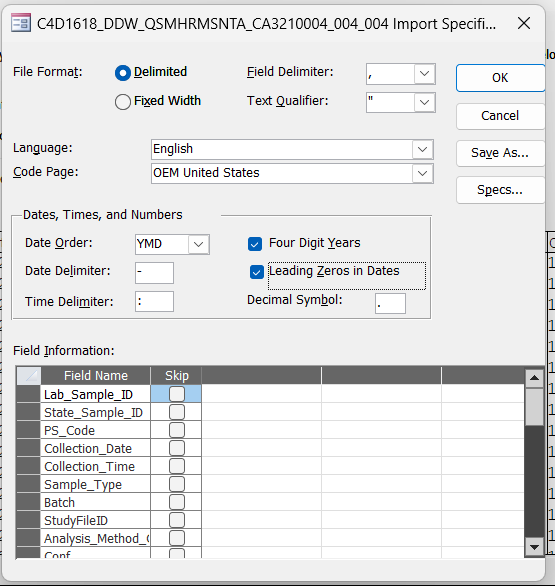

8. In the next window, click the `Finish` button.

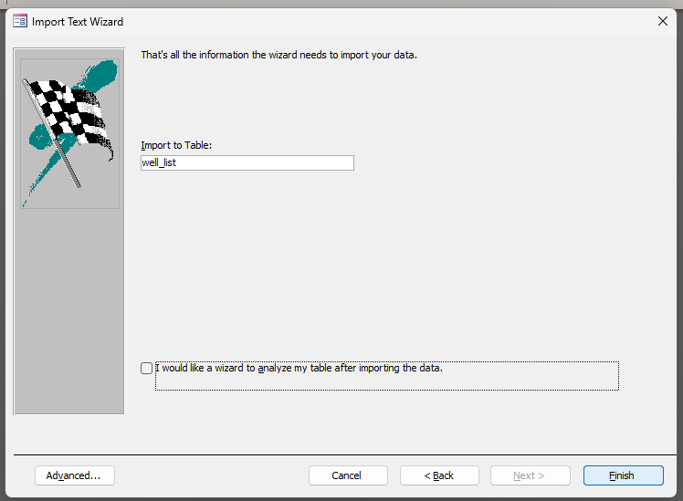

9. If there are any problems, you should get a popup window that briefly explains the issues (generally this starts with the message *“Microsoft Access was unable to append all the data to the table”)* and gives you an option to proceed with the import or cancel it.
   1. If there are problems converting some of the data to the correct type, you’ll see a message that says: “*the contents of fields in ## record(s) were deleted*”. Often, this just occurs because there is a missing / `NULL` / `NA` value in a numeric field, so in general it’s okay to proceed with the update even if this error is shown. In these cases, sometimes a new table will be added (in the ‘All Access Objects’ panel on the left side of the window), which will list each field / row where this issue occurred.

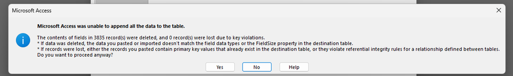

   2. If there is are duplicate records detected (i.e., a primary key violation), you’ll see a warning message that says “*## records were lost due to key violations*”. If you opt to proceed, the duplicate records are not imported to the database, but the rest of records are imported (**NOTE:** the `DB_Upload_DateTime` field may be useful in these cases to determine which records were duplicates / not uploaded); if you opt to cancel the import, none of the records will be uploaded.

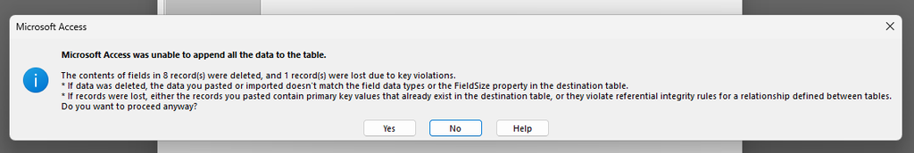